# Text processing in R

# 1 R basics. Link to courses

`R` is a popular language and environment for statistical computing and graphics, https://www.r-project.org/about.html, specially suited for working with arrays and matrices. Hundreds of manuals can be found for different levels of users. Just to name one, the following GitHub link learningRresources, covers a large set of resources of different starting levels. In the cheatsheets section of this repository, you can find a visual [review of `caret`](https://github.com/CABAH/learningRresources/blob/main/cheatsheets/caret.pdf). My experience also tells that the best way is to play and practice, nothing else.

`swirl` package provides an introduction to `R` by means of interactive courses. Type `?InstallCourses` at the `R` prompt for a list of functions that will help you to select a course fitted to your knowledge level and specific interests.

The language has a compact “core” and, by means of different packages programmed by the community, it is highly extensible. Thus, it nowadays offers tools (packages) to do specific computation and analysis in different domains such as bioinformatics, chemistry, computational physics, etc. Among those, the `tm` (text mining) [2, 1] package offers an interesting set of state-of-the-art functions to process text documents in an effective manner: creating a corpus, preprocessing-transformation operators, creating document-term matrices, etc. This tutorial is limited to these operations. Further, over these matrices, similar terms or documents can be clustered, and machine learning specialized packages (e.g. `caret` [4]) allow to train models to classify new documents in pre-defined classes-annotations.

Function `library("packageName")` loads the functions of a package. Prior to these, it is needed to install it by `install.packages("packageName")`. In order to install the needed packages, you will need full permission access in your computer. If you are working in the computers of our Faculty, you have root-full permission in the Windows version. Be careful, this does not happen in the Linux version.

`R`’s working directory can be consulted by `getwd()` and fixed by `setwd()`.

# 2 20 NewsGroup dataset

The 20 NewsGroup dataset ([LINK-ClickHere](http://qwone.com/~jason/20Newsgroups/)) is a popular NLP benchmark collection of approximately 20, 000 newsgroup documents, partitioned in 20 predefined thematic newsgroups. This tutorial is completed with the “20news-bydate.tar.gz” compressed file: you can find its link in the middle of the webpage. Unzip the compressed file: training and testing folders are created. Each of them contains 20 folders: each containing the text documents belonging to one newsgroup. We focus the tutorial on training “sci.electronics” and “talk.religion.misc” groups-folders. Focus in ‘training folders’ of “sci.electronics” and “talk.religion.misc”. We are going to treat them as documents belonging to two different classes-topics: science or religion.

Help for a function in R is obtained by invoking `?VCorpus` or `help(VCorpus)`. A good way to consult the different functions (and parameters) of each package is the https://www.rdocumentation.org/ community. In our case, the functions of the tm package, grouped alphabetically, can be consulted in https://www.rdocumentation.org/packages/tm/. I consider it as **mandatory** to develop your own text-preprocessing pipeline for your text and corpus. Searching in the web for the specific function, followed by the R term, usually produces good helping results.

# 3 Read documents

We start by **reading the documents of each subdirectory** (annotated document class) and loading them in a volatile corpora structure. Function inspect displays detailed information of the corpus. It is first needed to fix R in the working directory which saves the data-corpus, as previously exposed.

```r
library(tm)
sci.elec <- VCorpus(DirSource("../data/sci.electronics"), readerControl = list(language = "en"))
talk.religion <- VCorpus(DirSource("../data/talk.religion.misc"), readerControl = list(language = "en"))
sci.elec # dimension of the corpus
```

```
<<VCorpus>>
Metadata:  corpus specific: 0, document level (indexed): 0
Content:  documents: 591
```

```r
inspect(sci.elec[1]) # first document of the corpus, or sci.elec.train[[1]]
```

```
<<VCorpus>>
Metadata:  corpus specific: 0, document level (indexed): 0
Content:  documents: 1

[[1]]
<<PlainTextDocument>>
Metadata:  7
Content:  chars: 1994
```

```r
inspect(sci.elec[1:3]) # first three documents of the corpus
```

```
<<VCorpus>>
Metadata:  corpus specific: 0, document level (indexed): 0
Content:  documents: 3

[[1]]
<<PlainTextDocument>>
Metadata:  7
Content:  chars: 1994

[[2]]
<<PlainTextDocument>>
Metadata:  7
Content:  chars: 5406

[[3]]
<<PlainTextDocument>>
Metadata:  7
Content:  chars: 2788
```

# 4 Apply transformations

Transformations operators to the corpus are applied via `tm_map` function, which applies (maps) a function to all elements of the corpus. As the same transformations will be applied to both “science” and “religion” newsgroups, both corpus are merged using base function `c()`: this `c()` operator concatenates objects. This operation raises a collection of 968 documents. Function tm map applies transformations to corpus objects. The list of available transformations can be obtained consulting the help of ?getTransformations. Function content transformer is used to apply customized transformations. We apply several transformations. As NLP practitioner: consult the help and parameters of each transformation’s functions, of course, use them in a different and richer way then me.

```r
sci.rel <- c(sci.elec, talk.religion) # merge, concatenate both groups-corpuses
?getTransformations
sci.rel.trans <- tm_map(sci.rel, removeNumbers)
sci.rel.trans <- tm_map(sci.rel.trans, removePunctuation)
sci.rel.trans <- tm_map(sci.rel.trans, content_transformer(tolower)) # convert to lowercase
stopwords("english") # list of english stopwords
```

```
  [1] "i"          "me"         "my"         "myself"     "we"
  [6] "our"        "ours"       "ourselves"  "you"        "your"
 [11] "yours"      "yourself"   "yourselves" "he"         "him"
 [16] "his"        "himself"    "she"        "her"        "hers"
 [21] "herself"    "it"         "its"        "itself"     "they"
 [26] "them"       "their"      "theirs"     "themselves" "what"
 [31] "which"      "who"        "whom"       "this"       "that"
 [36] "these"      "those"      "am"         "is"         "are"
 [41] "was"        "were"       "be"         "been"       "being"
 [46] "have"       "has"        "had"        "having"     "do"
 [51] "does"       "did"        "doing"      "would"      "should"
 [56] "could"      "ought"      "i'm"        "you're"     "he's"
 [61] "she's"      "it's"       "we're"      "they're"    "i've"
 [66] "you've"     "we've"      "they've"    "i'd"        "you'd"
 [71] "he'd"       "she'd"      "we'd"       "they'd"     "i'll"
```

[output cut: 20 more lines]

```r
sci.rel.trans <- tm_map(sci.rel.trans, removeWords, stopwords("english"))
sci.rel.trans <- tm_map(sci.rel.trans, stripWhitespace)
library(SnowballC) # to access Porter's word stemming algorithm
sci.rel.trans <- tm_map(sci.rel.trans, stemDocument)
```

# 5 Create a document-term matrix

After corpus set transformation, a common approach in text mining is to **create a document-term matrix** from a corpus. Its transpose operator creates a term-document matrix. This document-term matrix is the starting point to apply machine-learning modelization techniques such as classification, clustering, etc. Different operations can be applied over this matrix. We can obtain the terms that occur at least, let say, 15 times; or consult the **terms that associate** with at least, for example, by a 0.7 correlation degree with the term “young”. After all, it is easy no note the huge degree of sparsity of this matrix: a low amount of non-zero elements. Thus, one of the most important operations is to remove sparse terms, i.e., terms occurring in very few documents. The sparse parameter in the removeSparseTerms function refers to the maximum sparseness allowed: the smaller its proportion, fewer terms (but more common) will be retained. A “trial-anerror” approach will finally return a proper number of terms. This matrix will be the starting point for building further machine learning models (in the next tutorial).

```r
sci.rel.dtm <- DocumentTermMatrix(sci.rel.trans)
dim(sci.rel.dtm)
```

```
[1]   968 13565
```

```r
inspect(sci.rel.dtm[15:25, 1040:1044]) # inspecting a subset of the matrix
```

```
<<DocumentTermMatrix (documents: 11, terms: 5)>>
Non-/sparse entries: 0/55
Sparsity           : 100%
Maximal term length: 8
Weighting          : term frequency (tf)
Sample             :
       Terms
Docs    bargain bargin bargraph bari barn
  52729       0      0        0    0    0
  52730       0      0        0    0    0
  52731       0      0        0    0    0
  52732       0      0        0    0    0
  52733       0      0        0    0    0
  52734       0      0        0    0    0
  52735       0      0        0    0    0
  52736       0      0        0    0    0
  52737       0      0        0    0    0
  52738       0      0        0    0    0
  52739       0      0        0    0    0
```

```r
findFreqTerms(sci.rel.dtm, 15)
```

```
   [1] "aaron"                  "abandon"                "abil"
   [4] "abl"                    "abort"                  "absolut"
   [7] "accept"                 "access"                 "accord"
  [10] "account"                "accur"                  "accuraci"
  [13] "accus"                  "acknowledg"             "across"
  [16] "act"                    "action"                 "activ"
  [19] "actual"                 "adcom"                  "add"
  [22] "addit"                  "address"                "admit"
  [25] "advanc"                 "advertis"               "advic"
  [28] "affect"                 "age"                    "agent"
  [31] "ago"                    "agre"                   "air"
  [34] "alan"                   "alicea"                 "alink"
  [37] "aliv"                   "allah"                  "allow"
  [40] "almost"                 "alon"                   "along"
  [43] "alreadi"                "also"                   "altern"
```

[output cut: 320 more lines]

```r
findAssocs(sci.rel.dtm, term = "young", corlimit = 0.7)
```

```
$young
                brigham                   antip                   apost
                   0.90                    0.77                    0.77
                aptitud               auxiliari                balloney
                   0.77                    0.77                    0.77
               bequeath                 carthag                 categor
                   0.77                    0.77                    0.77
               claimant                    cosi                 cowderi
                   0.77                    0.77                    0.77
           doityourself                  dukaki                excommun
                   0.77                    0.77                    0.77
                   exot                    fbis                  forbad
                   0.77                    0.77                    0.77
                glacier                    heir                  hoover
                   0.77                    0.77                    0.77
                  hyram                   hyrum               intensifi
                   0.77                    0.77                    0.77
                   jail               largescal                  mammon
                   0.77                    0.77                    0.77
                mcclari mcclarycsnpqkbnetcomcom        mcclarynetcomcom
                   0.77                    0.77                    0.77
             militarist                  nauvoo                   penal
                   0.77                    0.77                    0.77
              personnel                   pledg                  plural
                   0.77                    0.77                    0.77
              preposter           pseudographia                   purif
                   0.77                    0.77                    0.77
                 quorum                rekhabit                 reorgan
                   0.77                    0.77                    0.77
                 resili                  retort                    rlds
                   0.77                    0.77                    0.77
            selfprotect                sorenson                    staf
                   0.77                    0.77                    0.77
                tabloid                 tobacco                  tought
                   0.77                    0.77                    0.77
                underag                undertak                   unifi
                   0.77                    0.77                    0.77
                upbring                  vacanc        vikingiastateedu
                   0.77                    0.77                    0.77
                   wedg     zdanexnetiastateedu               latterday
                   0.77                    0.77                    0.75
                   salt                    sect          isscckvmbyuedu
                   0.75                    0.74                    0.73
               splinter                   smith                     lds
                   0.73                    0.71                    0.70
```

```r
sci.rel.dtm.70 <- removeSparseTerms(sci.rel.dtm, sparse = 0.7)
sci.rel.dtm.70 # or dim(sci.rel.dtm.70)
```

```
<<DocumentTermMatrix (documents: 968, terms: 14)>>
Non-/sparse entries: 7191/6361
Sparsity           : 47%
Maximal term length: 15
Weighting          : term frequency (tf)
```

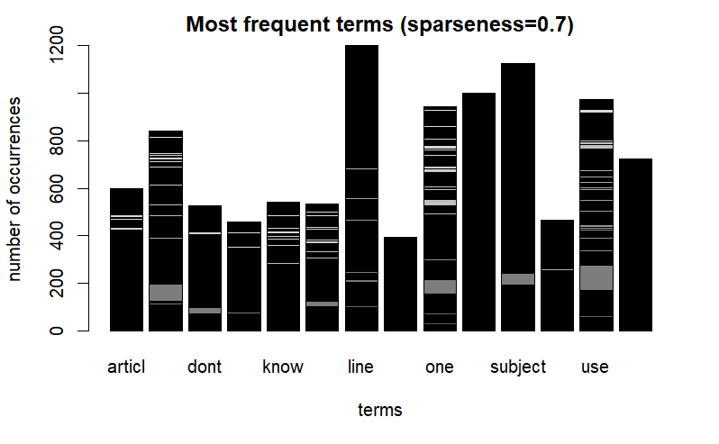

```r
# note that the term-document matrix needs to be transformed (casted)
# to a matrix form in the following barplot command
barplot(as.matrix(sci.rel.dtm.70),
    xlab = "terms", ylab = "number of occurrences",
    main = "Most frequent terms (sparseness=0.7)"
)
```

```r
sci.rel.dtm.80 <- removeSparseTerms(sci.rel.dtm, sparse = 0.8)
sci.rel.dtm.80
```

```
<<DocumentTermMatrix (documents: 968, terms: 32)>>
Non-/sparse entries: 11219/19757
Sparsity           : 64%
Maximal term length: 15
Weighting          : term frequency (tf)
```

```r
sci.rel.dtm.90 <- removeSparseTerms(sci.rel.dtm, sparse = 0.9)
sci.rel.dtm.90
```

```
<<DocumentTermMatrix (documents: 968, terms: 118)>>
Non-/sparse entries: 22176/92048
Sparsity           : 81%
Maximal term length: 15
Weighting          : term frequency (tf)
```

```r
save(list = c("sci.rel.dtm.80", "sci.rel.dtm.90"), file = "../data/sci.rel.dtm.Rdata")
```

# 6 Convert the “DocumentTerm matrix” to WEKA’s *.arff data format

Different functionalities of R allow to convert these matrices to the file format demanded by other software tools. For example, the function write.arff of the foreign package converts a data matrix or data frame to the well-known arff (“attribute relation format file”) of WEKA software. Note that a class vector is appended to the document-term matrix, labeling the type of each document. In my case (total numbers can be different in your corpus), the first 591 documents cover the “science-electronics” newgroup

```r
data <- data.frame(as.matrix(sci.rel.dtm.90)) # convert corpus to dataFrame format
type <- c(rep("science", 591), rep("religion", 377)) # create the type vector to be appended
# install the package for apply the conversion function
install.packages("foreign")
library(foreign)
write.arff(cbind(data, type), file = "../data/term-document-matrix-weka-format.arff")
# you can try to open the new .arff file in WEKA...
```

# 7 Build a wordcloud

Before starting learning the exposed machine learning models, let’s build a wordcloud with the following package [3]. Its wordcloud() command needs the list of words and their frequencies as parameters. As the words appear in columns in the document-term matrix, the colSums command is used to calculate the word frequencies. In order to complete the needed calculations, note that the term-document matrix needs to be transformed (casted) to a matrix form with the as.matrix cast-operator. It is built for the “talk.religion” newsgroup: it covers the 591-968 range of samples-documents (rows) in the document-term matrix. Let’s play yourself with the options-parameters of the wordcloud function: it offers many options to become the wordcloud more attractive, discover by yourself.

[output not shown]

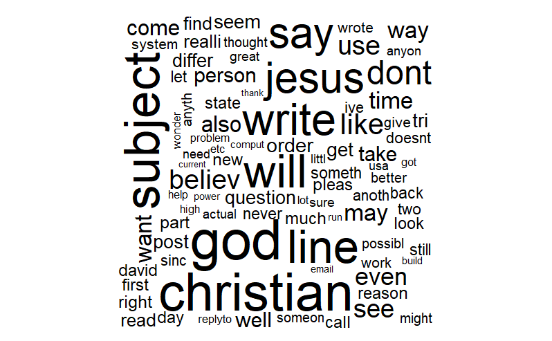

```r
library(wordcloud)
# calculate the frequency of words and sort in descending order.
wordFreqs <- sort(colSums(as.matrix(sci.rel.dtm.90)[591:968, ]), decreasing = TRUE)
wordcloud(words = names(wordFreqs), freq = wordFreqs)
```

# 8 Retrieve text and create a corpus from html pages

```r
indemnifications.HTML.page <- readLines("https://www.google.com/analytics/terms/us.html")
length(indemnifications.HTML.page)
```

```
[1] 1786
```

```r
text.data <- indemnifications.HTML.page[302:325] # 24 lines of desired text
text.data <- gsub(pattern = "<p>", replacement = "", x = text.data)
text.data <- gsub(pattern = "</p>", replacement = "", x = text.data)
text.data <- gsub(pattern = "</h2>", replacement = "", x = text.data)
text.data <- gsub(pattern = "<h2>", replacement = "", x = text.data)
text.data
```

```
 [1] "                  <li class=\"dd-menu__nav-item\" aria-level=\"2\">"
 [2] "                    <a data-g-event=\"terms: us\" data-g-action="
 [3] "                    \"for enterprises: analytics 360\" data-g-label="
 [4] "                    \"global nav\" href=\"/about/analytics-360/\""
 [5] "                    class=\"dd-menu__nav-item__link\"><span class="
 [6] "                    \"dd-menu__nav-item__title\">Analytics 360</span>"
 [7] "                    <p class=\"dd-menu__nav-item__desc\">"
 [8] "                      Use advanced tools to get a deeper"
 [9] "                      understanding of your customers so you can"
[10] "                      deliver better experiences."
[11] "                    </a>"
[12] "                  </li>"
[13] "                  <li class=\"dd-menu__nav-item\" aria-level=\"2\">"
[14] "                    <a data-g-event=\"terms: us\" data-g-action="
[15] "                    \"for enterprises: data studio\" data-g-label="
[16] "                    \"global nav\" href=\"/about/data-studio/\" class="
[17] "                    \"dd-menu__nav-item__link\"><span class="
[18] "                    \"dd-menu__nav-item__title\">Data Studio</span>"
[19] "                    <p class=\"dd-menu__nav-item__desc\">"
[20] "                      Unlock insights from your data with engaging,"
[21] "                      customizable reports."
[22] "                    </a>"
[23] "                  </li>"
[24] "                  <li class=\"dd-menu__nav-item\" aria-level=\"2\">"
```

```r
text.data <- VectorSource(text.data) # interpreting each element of the vector as a document
text.data.corpus <- VCorpus(text.data) # from document list to corpus
```

# 9 Retrieve text and create a corpus from files (stored in disk)

Other common practice to retrieve text is by means of the examples stored by R packages. In this case, when installing the tm package a set of document collections are stored in hard disk. Among them, a subset of the popular “Reuters-21578” collection. The system.file function points the subdirectory-tree that has the documents of interest in our package. When reading the text, an specific XML reader developed by the community, known as “readReut21578XMLasPlain”, is needed.

```r
reut21578 <- system.file("texts", "crude", package = "tm")
reut21578
```

```
[1] "C:/Users/julet/Documents/R/win-library/4.1/tm/texts/crude"
```

```r
reuters <- VCorpus(DirSource(reut21578), readerControl = list(reader = readReut21578XMLasPlain))
```

# 10 Retrieve text and create an annotated corpus from Twitter: using rtweet or twitteR packages

A fashion way to retrieve text is via Twitter posts. The twitteR library provides access to Twitter data. Twitter marks its use as the ‘official’ way to download its tweets. (In case you have problems with twitter package, I show you an alternative at the end of this subsection)

Second, I try to explain you the ‘official’ way offered by the twitteR library. Twitter API requires identification-authentification: follow these instructions: http://thinktostart.com/twitter-authentification-with-r/.

Pay attention, the current Twitter’s link to create Twitter applications is https://developer.twitter.com/en/apps. You need to be logged. It is needed to “create a new app”: this will provide you a set of 4 items related to the application called “consumerKey”, “consumerSecret”, “accessToken” and “accessSecret”. Both ’accessToken” and “accessSecret” need to be activated after receiving the “consumerKey” and “consumerSecret”. Four parameters need to be used in the final authentification function call in R, setup twitter oauth().

An alternative explanation, by twitter, of the exposed process. The following https://dev.twitter.com/oauth/overview/application-owner-access-tokens also explains the exposed Twitter’s identification-authentification process, which hangs from the general Twitter Developer Documentation https://developer.twitter.com/en/docs/authentication/overview

```r
library(twitteR)
source("twitter_oauth.R")
setup_twitter_oauth(consumer_key, consumer_secret, access_key, access_secret)
```

```
[1] "Using direct authentication"
```

While it is true that you can find many short guides to establish the connection with twitter in order to start downloading its text, I just offer you another pointer: https://www.kdnuggets.com/2017/11/extracting-tweets-r.html

Once the authentification is done, tweets of any user or hashtag can be retrieved and converted to a corpus. The functions provided by the twitteR package evolve continuously and sure that you find interesting functions for your NLP analysis objectives.

Just an idea. To further apply machine learning techniques to learn supervised classifiers, our corpus needs to have documents with different annotations-types: confronting two antagonistic users and downloading their tweets, an annotated, binary corpus can be constructed. After preprocessing and converting the corpus to a data frame format, supervised classification techniques can be applied over it.

```r
# consult the different ways to retrieve tweets: from an user or from a hashtag
?userTimeline
?searchTwitteR
LadyGagaTweets <- userTimeline(user = "ladygaga", n = 100)
CristianoRonaldoTweets <- userTimeline(user = "Cristiano", n = 100)
# beerTweets = searchTwitteR(searchString = "#beer", n=100)
length(LadyGagaTweets)
```

```
[1] 87
```

```r
LadyGagaTweets[1:4]
```

```
[[1]]
[1] "ladygaga: Last chance to shop the @hauslabs end-of-year sale with promo code BYE2021 💕 https://t.co/16HKLF1qsu https://t.co/E5UHLEaBIa"

[[2]]
[1] "ladygaga: The @hauslabs end-of-year sale is happening now! Use promo code BYE2021 on my favorites like the gel pencil eyeline… https://t.co/heqFIwkCXo"

[[3]]
[1] "ladygaga: My friend Dr. Paul Conti wrote a great book about trauma, and I was proud to write the foreword for him. This book… https://t.co/dB8XqkMJRa"

[[4]]
[1] "ladygaga: Nightmare Alley is an amazing film with an amazing cast, congratulations to @RealGDT. Bradley is spectacular, Cate… https://t.co/DrGVhx7WI5"
```

```r
# convert each tweet to a data frame and combine them by rows
LadyGagaTweetsDataFrames <- do.call("rbind", lapply(LadyGagaTweets, as.data.frame))
CristianoRonaldoTweetsDataFrames <- do.call("rbind", lapply(CristianoRonaldoTweets, as.data.frame))
# consult the different attributes of these object using \£ symbol
LadyGagaTweetsDataFrames$text
```

```
 [1] "Last chance to shop the @hauslabs end-of-year sale with promo code BYE2021 💕 https://t.co/16HKLF1qsu https://t.co/E5UHLEaBIa"
 [2] "The @hauslabs end-of-year sale is happening now! Use promo code BYE2021 on my favorites like the gel pencil eyeline… https://t.co/heqFIwkCXo"
 [3] "My friend Dr. Paul Conti wrote a great book about trauma, and I was proud to write the foreword for him. This book… https://t.co/dB8XqkMJRa"
 [4] "Nightmare Alley is an amazing film with an amazing cast, congratulations to @RealGDT. Bradley is spectacular, Cate… https://t.co/DrGVhx7WI5"
 [5] "There's glam, then there's #ItalianGlam 🇮🇹 The @hauslabs Casa Gaga Highlighter, All-Over Rouge &amp; Mini Lipsticks are… https://t.co/dtRznNpVH6"
 [6] "🎺🎹🤍 https://t.co/tOsDb2mIWP"
 [7] "Thank you @MTV for such a special night celebrating Love For Sale ❤️✨ If you weren’t able to tune in to our… https://t.co/B9IDlWtEfR"
 [8] ". @BTWFoundation 💕💕💕https://t.co/Ro58UCkzZd"
 [9] "Tune in tonight to celebrate #LoveForSale with @itstonybennett and me during our #MTVUnplugged special! Join us at… https://t.co/iB9GfveFNr"
[10] "#ItalianGlam 🇮🇹❤️ @hauslabs https://t.co/tPWgGhWLLa https://t.co/JEz4HHtw40"
[11] "The brand new Lady Gaga Music Pack is available now on @BeatSaber for @Oculus Quest 2! Experience handmade levels f… https://t.co/vqbSsriKUV"
[12] "Thank you @RadioCity! 🥰❤️✨ @itstonybennett #LoveForSale https://t.co/XP4GZgp8Nt"
[13] "I brought the @hauslabs Tanti Baci Extreme Creme Mini Lipsticks to Italy while filming #HouseofGucci 💋 5 creamy &amp; l… https://t.co/6xUlWNPaNK"
[14] "The limited edition “Love For Sale” cream vinyl is now available, only at Amazon! @itstonybennett @amazonmusic ❤️… https://t.co/B2jr4f1O51"
[15] "@hauslabs @NikkieTutorials 😆"
```

[output cut: 72 more lines]

```r
# combine both frames in a single, binary, annotated set
annotatedTweetsDataFrames <- rbind(LadyGagaTweetsDataFrames, CristianoRonaldoTweetsDataFrames)
# interpreting each element of the annotated vector as a document
annotatedDocuments <- VectorSource(annotatedTweetsDataFrames$text)
# convert to a corpus: supervised classification to be applied in future steps
annotatedCorpus <- VCorpus(annotatedDocuments)
```

In case you had problems with twitter package, an attractive and ‘easy-to-use’ alternative to Twitter’s ‘official rules’ is based on the use of the rtweet package. The [following link](https://github.com/ropensci/rtweet) seems to be a ‘more updated’ package. I think it is needed to have a Twitter account (username and password). This [set of slides](https://mkearney.github.io/nicar_tworkshop/) offers an easy-to-follow tutorial, showing the pipeline that you need.

# 11 Bibliography

[1] Ingo Feinerer. tm: Text Mining Package, 2012. R package version 0.5-7.1.

[2] Ingo Feinerer, Kurt Hornik, and David Meyer. Text mining infrastructure in R. Journal of Statistical Software, 25(5):1–54, 3 2008.

[3] Ian Fellows. wordcloud: Word Clouds, 2014. R package version 2.5.

[4] M. Kuhn and K. Johnson. Applied Predictive Modeling. Springer, 2013.